# Emory_ICU_Analysis_Notebook

## In this notebook, we will present the analysis that we did on the Emory ICU dataset

```python
import os

import duckdb
import pandas as pd
import pyarrow.parquet as pq
import seaborn as sns
import matplotlib as mpl
import matplotlib.pyplot as plt

# set global parameters
sns.set(font_scale=2)  # increase text size
mpl.rcParams['xtick.labelsize'] = 20
mpl.rcParams['ytick.labelsize'] = 20
```

## Overview of tables in the dataset

The Emory-ICU data has the following tables:

- patients, admissions, transfers, icustays
  - tracking the patient throughout their hospital stay
- chartevents, d_items
  - charted measurements (ventilator settings, vital signs, etc)
- procedureevents
  - invasive ventilation durations
- labevents, d_labitems
  - lab measurements (chemistry, hematology, etc)
- microbiologyevents
  - microbiology measurements (blood cultures, etc)
- emar, emar_detail
  - medication administration
- diagnoses_icd, d_icd_diagnoses
  - hospital billing diagnoses
- hcpcsevents, d_hcpcs
  - billed procedures (CPT codes)

Most of the tables in MIMIC-IV are in Emory-ICU. In fact some tables are more expansive. Even though *chartevents* was an ICU only table in MIMIC-IV, it's actually hospital wide for Emory.

Nevertheless, if you are familiar with MIMIC-IV, note the following concepts (and associated tables) are not present in Emory-ICU (currently!):

- provider, caregiver
  - unique identifiers for each provider/caregiver. links to provider_id and caregiver_id.
- datetimeevents, ingredientevents, inputevents, outputevents
  - various charted data in the icu
- pharmacy
  - dispensation for medications
- prescriptions, poe, poe_detail
  - orders made by providers such as orders for medications (prescriptions), orders for x-rays, etc.
- procedures_icd, d_icd_procedures
  - hospital billed procedures

## Patient tracking

Patients are tracked through a few tables:

- patients - unique row per `subject_id`, and provides patient demographics
- admissions - unique row per `hadm_id`, and provides information about hospitalizations
- transfers - unique row per hospital transfer
- icustays - a subset of the *transfers* table, which groups together ICU stays which are contiguous

First, let's import the admissions.parquet, icustays.parquet, and patients.parquet files:

```python
patients = pd.read_parquet('/icu/emory/patients.parquet')
admissions = pd.read_parquet('/icu/emory/admissions.parquet')
transfers = pd.read_parquet('/icu/emory/transfers.parquet')
icustays = pd.read_parquet('/icu/emory/icustays.parquet')
```

```python
icustays
```

[output not shown]

## Getting the hospitals' names

```python
icustays["first_careunit"]
```

```
0           5E ICU EUH
1           5E ICU EUH
2           5E ICU EUH
3          2SW ICU SJH
4           5E ICU EUH
              ...
189220     41 CCU ECLH
189221     41 CCU ECLH
189222    PACU II ECLH
189223     2SW ICU SJH
189224      3G CCU EUH
Name: first_careunit, Length: 189225, dtype: object
```

```python
icustays["first_careunit"].str[-4:].unique()
```

```
array([' EUH', ' SJH', 'ECLH', 'EJCH', 'U NL'], dtype=object)
```

## Getting the total ICU stays in the hospitals

```python
# Create a new column with the last 4 characters
icustays['hospital_name'] = icustays['first_careunit'].str[-4:]

# Get value counts for the groups
value_counts = icustays['hospital_name'].value_counts()
value_counts
```

```
hospital_name
 EUH    81951
ECLH    62271
 SJH    31349
EJCH     9791
U NL     3863
Name: count, dtype: int64
```

## Getting the LOS and removing the outliers

```python
icustays["los"].describe()
```

```
count    189225.000000
mean          4.279688
std          10.270914
min           0.041863
25%           1.140949
50%           2.105695
75%           4.227766
max        2490.347168
Name: los, dtype: float64
```

```python
icustays['los'] = pd.to_numeric(icustays['los'], errors='coerce')

mean = icustays['los'].mean()
std = icustays['los'].std()

# Calculate the threshold for values to be kept
threshold = mean + 3 * std

# Filter out values greater than the threshold
icustays_1 = icustays[icustays['los'] <= threshold]

# Print the filtered DataFrame
icustays_1
```

|  | subject_id | hadm_id | stay_id | first_careunit | last_careunit | intime | outtime | los | hospital_name |
| --- | --- | --- | --- | --- | --- | --- | --- | --- | --- |
| 0 | 10000683 | 29770490036 | 1 | 5E ICU EUH | 5E ICU EUH | 2015-05-12 18:29:30 | 2015-05-13 16:51:55 | 0.932234 | EUH |
| 1 | 10000683 | 29770490036 | 2 | 5E ICU EUH | 5E ICU EUH | 2015-05-13 17:16:17 | 2015-05-13 22:14:51 | 0.207338 | EUH |
| 2 | 10000683 | 87659254514 | 3 | 5E ICU EUH | 5E ICU EUH | 2015-09-08 12:10:12 | 2015-09-09 14:28:37 | 1.096123 | EUH |
| 3 | 10000788 | 54733468003 | 4 | 2SW ICU SJH | 2SW ICU SJH | 2017-02-01 14:17:11 | 2017-02-12 10:27:44 | 10.840660 | SJH |
| 4 | 10001527 | 90885934252 | 5 | 5E ICU EUH | 5E ICU EUH | 2012-09-27 21:45:17 | 2012-09-28 15:00:27 | 0.718866 | EUH |
| ... | ... | ... | ... | ... | ... | ... | ... | ... | ... |
| 189220 | 99995283 | 41747642827 | 189221 | 41 CCU ECLH | 41 CCU ECLH | 2015-05-17 07:53:44 | 2015-05-18 15:39:21 | 1.323345 | ECLH |
| 189221 | 99995283 | 76374197374 | 189222 | 41 CCU ECLH | 41 CCU ECLH | 2018-04-08 20:56:03 | 2018-04-09 17:58:46 | 0.876887 | ECLH |
| 189222 | 99995283 | 98208879646 | 189223 | PACU II ECLH | 21 ICU ECLH | 2010-12-28 06:16:21 | 2010-12-29 12:13:20 | 1.247905 | ECLH |
| 189223 | 99997196 | 59639511443 | 189224 | 2SW ICU SJH | 2SW ICU SJH | 2017-09-23 12:38:48 | 2017-09-24 15:21:54 | 1.113264 | SJH |
| 189224 | 99997229 | 71249926344 | 189225 | 3G CCU EUH | 3G CCU EUH | 2021-03-20 01:33:40 | 2021-03-22 21:10:46 | 2.817430 | EUH |

187686 rows × 9 columns

```python
icustays_1["los"].describe()
```

```
count    187686.000000
mean          3.806051
std           4.771841
min           0.041863
25%           1.135550
50%           2.090370
75%           4.138328
max          35.091587
Name: los, dtype: float64
```

```python
hospital_means = icustays.groupby('hospital_name')['los'].mean()
hospital_means
```

```
hospital_name
 EUH    5.219727
 SJH    3.313033
ECLH    3.781088
EJCH    3.329447
U NL    2.627791
Name: los, dtype: float32
```

## Merging with Race, Gender and Age

```python
admissions = pd.read_parquet('/icu/mimic/admissions.parquet')
race=admissions[["subject_id","race"]]
race=race.drop_duplicates()
race=race.reset_index()
race=race.drop(["index"],axis=1)
race
```

|  | subject_id | race |
| --- | --- | --- |
| 0 | 10000032 | WHITE |
| 1 | 10000068 | WHITE |
| 2 | 10000084 | WHITE |
| 3 | 10000108 | WHITE |
| 4 | 10000117 | WHITE |
| ... | ... | ... |
| 189925 | 19999733 | WHITE |
| 189926 | 19999784 | BLACK/AFRICAN AMERICAN |
| 189927 | 19999828 | WHITE |
| 189928 | 19999840 | WHITE |
| 189929 | 19999987 | UNKNOWN |

189930 rows × 2 columns

```python
document_dict_1 = pd.Series(race.race.values,index = race.subject_id).to_dict()
icustays_1['race'] = icustays_1['subject_id'].map(document_dict_1)
icustays_1
```

|  | subject_id | hadm_id | stay_id | first_careunit | last_careunit | intime | outtime | los | hospital_name | race |
| --- | --- | --- | --- | --- | --- | --- | --- | --- | --- | --- |
| 0 | 10000683 | 29770490036 | 1 | 5E ICU EUH | 5E ICU EUH | 2015-05-12 18:29:30 | 2015-05-13 16:51:55 | 0.932234 | EUH | NaN |
| 1 | 10000683 | 29770490036 | 2 | 5E ICU EUH | 5E ICU EUH | 2015-05-13 17:16:17 | 2015-05-13 22:14:51 | 0.207338 | EUH | NaN |
| 2 | 10000683 | 87659254514 | 3 | 5E ICU EUH | 5E ICU EUH | 2015-09-08 12:10:12 | 2015-09-09 14:28:37 | 1.096123 | EUH | NaN |
| 3 | 10000788 | 54733468003 | 4 | 2SW ICU SJH | 2SW ICU SJH | 2017-02-01 14:17:11 | 2017-02-12 10:27:44 | 10.840660 | SJH | NaN |
| 4 | 10001527 | 90885934252 | 5 | 5E ICU EUH | 5E ICU EUH | 2012-09-27 21:45:17 | 2012-09-28 15:00:27 | 0.718866 | EUH | NaN |
| ... | ... | ... | ... | ... | ... | ... | ... | ... | ... | ... |
| 189220 | 99995283 | 41747642827 | 189221 | 41 CCU ECLH | 41 CCU ECLH | 2015-05-17 07:53:44 | 2015-05-18 15:39:21 | 1.323345 | ECLH | NaN |
| 189221 | 99995283 | 76374197374 | 189222 | 41 CCU ECLH | 41 CCU ECLH | 2018-04-08 20:56:03 | 2018-04-09 17:58:46 | 0.876887 | ECLH | NaN |
| 189222 | 99995283 | 98208879646 | 189223 | PACU II ECLH | 21 ICU ECLH | 2010-12-28 06:16:21 | 2010-12-29 12:13:20 | 1.247905 | ECLH | NaN |
| 189223 | 99997196 | 59639511443 | 189224 | 2SW ICU SJH | 2SW ICU SJH | 2017-09-23 12:38:48 | 2017-09-24 15:21:54 | 1.113264 | SJH | NaN |
| 189224 | 99997229 | 71249926344 | 189225 | 3G CCU EUH | 3G CCU EUH | 2021-03-20 01:33:40 | 2021-03-22 21:10:46 | 2.817430 | EUH | NaN |

187686 rows × 10 columns

```python
gender=patients[["subject_id","gender"]]

age=patients[["subject_id","anchor_age"]]

age
```

|  | subject_id | anchor_age |
| --- | --- | --- |
| 0 | 10000100 | 70 |
| 1 | 10000562 | 18 |
| 2 | 10000671 | 28 |
| 3 | 10000683 | 34 |
| 4 | 10000788 | 83 |
| ... | ... | ... |
| 492104 | 99999419 | 47 |
| 492105 | 99999577 | 60 |
| 492106 | 99999731 | 38 |
| 492107 | 99999856 | 69 |
| 492108 | 99999997 | 70 |

492109 rows × 2 columns

```python
document_dict_2 = pd.Series(age.anchor_age.values,index = age.subject_id).to_dict()
document_dict_3 = pd.Series(gender.gender.values,index = gender.subject_id).to_dict()
icustays_1['age'] = icustays_1['subject_id'].map(document_dict_2)
icustays_1['gender']=icustays_1['subject_id'].map(document_dict_3)
icustays_1
```

|  | subject_id | hadm_id | stay_id | first_careunit | last_careunit | intime | outtime | los | hospital_name | race | age | gender |
| --- | --- | --- | --- | --- | --- | --- | --- | --- | --- | --- | --- | --- |
| 0 | 10000683 | 29770490036 | 1 | 5E ICU EUH | 5E ICU EUH | 2015-05-12 18:29:30 | 2015-05-13 16:51:55 | 0.932234 | EUH | NaN | 34.0 | Male |
| 1 | 10000683 | 29770490036 | 2 | 5E ICU EUH | 5E ICU EUH | 2015-05-13 17:16:17 | 2015-05-13 22:14:51 | 0.207338 | EUH | NaN | 34.0 | Male |
| 2 | 10000683 | 87659254514 | 3 | 5E ICU EUH | 5E ICU EUH | 2015-09-08 12:10:12 | 2015-09-09 14:28:37 | 1.096123 | EUH | NaN | 34.0 | Male |
| 3 | 10000788 | 54733468003 | 4 | 2SW ICU SJH | 2SW ICU SJH | 2017-02-01 14:17:11 | 2017-02-12 10:27:44 | 10.840660 | SJH | NaN | 83.0 | Female |
| 4 | 10001527 | 90885934252 | 5 | 5E ICU EUH | 5E ICU EUH | 2012-09-27 21:45:17 | 2012-09-28 15:00:27 | 0.718866 | EUH | NaN | 82.0 | Male |
| ... | ... | ... | ... | ... | ... | ... | ... | ... | ... | ... | ... | ... |
| 189220 | 99995283 | 41747642827 | 189221 | 41 CCU ECLH | 41 CCU ECLH | 2015-05-17 07:53:44 | 2015-05-18 15:39:21 | 1.323345 | ECLH | NaN | 60.0 | Female |
| 189221 | 99995283 | 76374197374 | 189222 | 41 CCU ECLH | 41 CCU ECLH | 2018-04-08 20:56:03 | 2018-04-09 17:58:46 | 0.876887 | ECLH | NaN | 60.0 | Female |
| 189222 | 99995283 | 98208879646 | 189223 | PACU II ECLH | 21 ICU ECLH | 2010-12-28 06:16:21 | 2010-12-29 12:13:20 | 1.247905 | ECLH | NaN | 60.0 | Female |
| 189223 | 99997196 | 59639511443 | 189224 | 2SW ICU SJH | 2SW ICU SJH | 2017-09-23 12:38:48 | 2017-09-24 15:21:54 | 1.113264 | SJH | NaN | 71.0 | Male |
| 189224 | 99997229 | 71249926344 | 189225 | 3G CCU EUH | 3G CCU EUH | 2021-03-20 01:33:40 | 2021-03-22 21:10:46 | 2.817430 | EUH | NaN | 65.0 | Male |

187686 rows × 12 columns

```python
# Group by "Hosp" and "Class", then count the occurrences
grouped = icustays_1.groupby(['hospital_name', 'race']).size().unstack(fill_value=0)

# Print the results
for hosp, row in grouped.iterrows():
    class_counts = ', '.join(f'{index}={count}' for index, count in row.items())
    print(f'{hosp}: {class_counts}')
```

[output not shown]

```python
# Group by "Hosp" and "Class", then count the occurrences
grouped = icustays_1.groupby(['hospital_name', 'gender']).size().unstack(fill_value=0)

# Print the results
for hosp, row in grouped.iterrows():
    class_counts = ', '.join(f'{index}={count}' for index, count in row.items())
    print(f'{hosp}: {class_counts}')
```

```
 EUH: Female=38617, Male=41939
 SJH: Female=12433, Male=18694
ECLH: Female=29759, Male=32009
EJCH: Female=4459, Male=5186
U NL: Female=2170, Male=1678
```

## Making the age groups

```python
def age_to_group(age):
    return f"{(age // 10) * 10}s"

# Apply the function to create a new column 'Age_Group' in the original DataFrame
icustays_1['age_group'] = icustays_1['age'].apply(age_to_group)

icustays_1
```

|  | subject_id | hadm_id | stay_id | first_careunit | last_careunit | intime | outtime | los | hospital_name | race | age | gender | age_group |
| --- | --- | --- | --- | --- | --- | --- | --- | --- | --- | --- | --- | --- | --- |
| 0 | 10000683 | 29770490036 | 1 | 5E ICU EUH | 5E ICU EUH | 2015-05-12 18:29:30 | 2015-05-13 16:51:55 | 0.932234 | EUH | NaN | 34.0 | Male | 30.0s |
| 1 | 10000683 | 29770490036 | 2 | 5E ICU EUH | 5E ICU EUH | 2015-05-13 17:16:17 | 2015-05-13 22:14:51 | 0.207338 | EUH | NaN | 34.0 | Male | 30.0s |
| 2 | 10000683 | 87659254514 | 3 | 5E ICU EUH | 5E ICU EUH | 2015-09-08 12:10:12 | 2015-09-09 14:28:37 | 1.096123 | EUH | NaN | 34.0 | Male | 30.0s |
| 3 | 10000788 | 54733468003 | 4 | 2SW ICU SJH | 2SW ICU SJH | 2017-02-01 14:17:11 | 2017-02-12 10:27:44 | 10.840660 | SJH | NaN | 83.0 | Female | 80.0s |
| 4 | 10001527 | 90885934252 | 5 | 5E ICU EUH | 5E ICU EUH | 2012-09-27 21:45:17 | 2012-09-28 15:00:27 | 0.718866 | EUH | NaN | 82.0 | Male | 80.0s |
| ... | ... | ... | ... | ... | ... | ... | ... | ... | ... | ... | ... | ... | ... |
| 189220 | 99995283 | 41747642827 | 189221 | 41 CCU ECLH | 41 CCU ECLH | 2015-05-17 07:53:44 | 2015-05-18 15:39:21 | 1.323345 | ECLH | NaN | 60.0 | Female | 60.0s |
| 189221 | 99995283 | 76374197374 | 189222 | 41 CCU ECLH | 41 CCU ECLH | 2018-04-08 20:56:03 | 2018-04-09 17:58:46 | 0.876887 | ECLH | NaN | 60.0 | Female | 60.0s |
| 189222 | 99995283 | 98208879646 | 189223 | PACU II ECLH | 21 ICU ECLH | 2010-12-28 06:16:21 | 2010-12-29 12:13:20 | 1.247905 | ECLH | NaN | 60.0 | Female | 60.0s |
| 189223 | 99997196 | 59639511443 | 189224 | 2SW ICU SJH | 2SW ICU SJH | 2017-09-23 12:38:48 | 2017-09-24 15:21:54 | 1.113264 | SJH | NaN | 71.0 | Male | 70.0s |
| 189224 | 99997229 | 71249926344 | 189225 | 3G CCU EUH | 3G CCU EUH | 2021-03-20 01:33:40 | 2021-03-22 21:10:46 | 2.817430 | EUH | NaN | 65.0 | Male | 60.0s |

187686 rows × 13 columns

```python
# Group by "Hosp" and "Class", then count the occurrences
grouped = icustays_1.groupby(['hospital_name', 'age_group']).size().unstack(fill_value=0)

# Print the results
for hosp, row in grouped.iterrows():
    class_counts = ', '.join(f'{index}={count}' for index, count in row.items())
    print(f'{hosp}: {class_counts}')
```

```
 EUH: 0.0s=0, 10.0s=882, 20.0s=5371, 30.0s=6849, 40.0s=11264, 50.0s=17060, 60.0s=19819, 70.0s=12486, 80.0s=6825, nans=300
 SJH: 0.0s=0, 10.0s=118, 20.0s=986, 30.0s=1458, 40.0s=3007, 50.0s=5629, 60.0s=8320, 70.0s=7222, 80.0s=4387, nans=122
ECLH: 0.0s=112, 10.0s=499, 20.0s=3141, 30.0s=4745, 40.0s=7878, 50.0s=12747, 60.0s=15638, 70.0s=11284, 80.0s=5724, nans=199
EJCH: 0.0s=78, 10.0s=95, 20.0s=336, 30.0s=522, 40.0s=954, 50.0s=1601, 60.0s=2127, 70.0s=2198, 80.0s=1734, nans=108
U NL: 0.0s=0, 10.0s=19, 20.0s=55, 30.0s=101, 40.0s=274, 50.0s=708, 60.0s=1261, 70.0s=1002, 80.0s=428, nans=13
```

## Previous tutorials...

```python
admissions = pd.read_parquet('../../icu/emory/admissions.parquet')
admissions
```

|  | subject_id | hadm_id | admittime | dischtime | deathtime | admission_type | admit_provider_id | admission_location | discharge_location | insurance | language | marital_status | race | edregtime | edouttime | hospital_expire_flag |
| --- | --- | --- | --- | --- | --- | --- | --- | --- | --- | --- | --- | --- | --- | --- | --- | --- |
| 0 | 10000100 | 58594204243 | 2019-06-26 13:20:00 | 2019-07-05 12:47:00 | NaT | None | None | PHYSIC OFC/CLINIC | HOME SELF CARE | MEDICARE A | None | None | African American or Black | NaT | NaT | 0 |
| 1 | 10000562 | 60707883031 | 2016-06-02 09:24:00 | 2016-06-04 15:11:00 | NaT | None | None | NON-HC FACILITY POO | HOME SELF CARE | MEDICAID | None | None | African American or Black | NaT | NaT | 0 |
| 2 | 10000671 | 67252991505 | 2019-05-14 20:20:00 | 2019-05-15 13:09:00 | NaT | None | None | NON-HC FACILITY POO | HOME SELF CARE | SELF PAY | None | None | African American or Black | NaT | NaT | 0 |
| 3 | 10000683 | 29770490036 | 2015-05-12 18:28:00 | 2015-05-17 15:55:00 | NaT | None | None | TRANSFER FROM HOSP | HOME SELF CARE | MANAGED CARE | None | None | Caucasian or White | NaT | NaT | 0 |
| 4 | 10000683 | 21514546148 | 2015-05-28 14:04:00 | 2015-06-03 19:03:00 | NaT | None | None | NON-HC FACILITY POO | HOME SELF CARE | MANAGED CARE | None | None | Caucasian or White | NaT | NaT | 0 |
| ... | ... | ... | ... | ... | ... | ... | ... | ... | ... | ... | ... | ... | ... | ... | ... | ... |
| 972842 | 99999731 | 37382428249 | 2009-11-24 12:50:00 | 2009-11-25 18:50:00 | NaT | None | None | Not Recorded | HOME SELF CARE | MANAGED CARE | None | None | African American or Black | NaT | NaT | 0 |
| 972843 | 99999731 | 58311570862 | 2010-06-28 15:23:00 | 2010-06-29 19:42:00 | NaT | None | None | NON-HC FACILITY POO | HOME SELF CARE | MANAGED CARE | None | None | African American or Black | NaT | NaT | 0 |
| 972844 | 99999731 | 55258667078 | 2010-11-20 13:01:00 | 2010-11-21 18:45:00 | NaT | None | None | NON-HC FACILITY POO | HOME SELF CARE | MANAGED CARE | None | None | African American or Black | NaT | NaT | 0 |
| 972845 | 99999856 | 39743800534 | 2019-09-21 08:20:00 | 2019-09-23 15:45:00 | NaT | None | None | NON-HC FACILITY POO | HOME SELF CARE | MEDICARE | None | None | Caucasian or White | NaT | NaT | 0 |
| 972846 | 99999997 | 48836056566 | 2018-02-13 22:44:00 | 2018-02-15 14:53:00 | NaT | None | None | NON-HC FACILITY POO | HOME SELF CARE | MEDICARE/BLUE CROSS | None | None | Caucasian or White | NaT | NaT | 0 |

972847 rows × 16 columns

We can take a look at rows in each table.

```python
print('=== patients ===')
display(patients.head())

print('=== icustays ===')
display(icustays.head())
```

```
=== patients ===
```

|  | subject_id | gender | anchor_age | anchor_year | anchor_year_group | dod |
| --- | --- | --- | --- | --- | --- | --- |
| 0 | 10000100 | Male | 70 | 2019 | 2017 - 2019 | None |
| 1 | 10000562 | Female | 18 | 2016 | 2014 - 2016 | None |
| 2 | 10000671 | Male | 28 | 2019 | 2017 - 2019 | None |
| 3 | 10000683 | Male | 34 | 2015 | 2014 - 2016 | None |
| 4 | 10000788 | Female | 83 | 2017 | 2017 - 2019 | None |

```
=== icustays ===
```

|  | subject_id | hadm_id | stay_id | first_careunit | last_careunit | intime | outtime | los |
| --- | --- | --- | --- | --- | --- | --- | --- | --- |
| 0 | 10000683 | 29770490036 | 1 | 5E ICU EUH | 5E ICU EUH | 2015-05-12 18:29:30 | 2015-05-13 16:51:55 | 0.932234 |
| 1 | 10000683 | 29770490036 | 2 | 5E ICU EUH | 5E ICU EUH | 2015-05-13 17:16:17 | 2015-05-13 22:14:51 | 0.207338 |
| 2 | 10000683 | 87659254514 | 3 | 5E ICU EUH | 5E ICU EUH | 2015-09-08 12:10:12 | 2015-09-09 14:28:37 | 1.096123 |
| 3 | 10000788 | 54733468003 | 4 | 2SW ICU SJH | 2SW ICU SJH | 2017-02-01 14:17:11 | 2017-02-12 10:27:44 | 10.840660 |
| 4 | 10001527 | 90885934252 | 5 | 5E ICU EUH | 5E ICU EUH | 2012-09-27 21:45:17 | 2012-09-28 15:00:27 | 0.718866 |

We can pick a single patient and look through their stay. Let's pick 10000788.

```python
subject_id = 10000788

print('=== patients ===')
display(patients.loc[patients['subject_id']==subject_id])

print('=== admissions ===')
display(admissions.loc[admissions['subject_id']==subject_id])

print('=== transfers ===')
display(transfers.loc[transfers['subject_id']==subject_id])

print('=== icustays ===')
display(icustays.loc[icustays['subject_id']==subject_id])
```

```
=== patients ===
```

|  | subject_id | gender | anchor_age | anchor_year | anchor_year_group | dod |
| --- | --- | --- | --- | --- | --- | --- |
| 4 | 10000788 | Female | 83 | 2017 | 2017 - 2019 | None |

```
=== admissions ===
```

|  | subject_id | hadm_id | admittime | dischtime | deathtime | admission_type | admit_provider_id | admission_location | discharge_location | insurance | language | marital_status | race | edregtime | edouttime | hospital_expire_flag |
| --- | --- | --- | --- | --- | --- | --- | --- | --- | --- | --- | --- | --- | --- | --- | --- | --- |
| 8 | 10000788 | 54733468003 | 2017-02-01 05:42:00 | 2017-02-22 14:54:00 | NaT | None | None | NON-HC FACILITY POO | SKILLED NURSING FAC | MEDICARE A | None | None | Caucasian or White | NaT | NaT | 0 |
| 9 | 10000788 | 41046337602 | 2019-02-14 15:41:00 | 2019-02-16 19:25:00 | NaT | None | None | NON-HC FACILITY POO | HOME SELF CARE | MEDICARE A | None | None | Caucasian or White | NaT | NaT | 0 |
| 10 | 10000788 | 88137573369 | 2019-02-19 16:27:00 | 2019-02-21 17:50:00 | NaT | None | None | NON-HC FACILITY POO | HOME SELF CARE | MEDICARE B | None | None | Caucasian or White | NaT | NaT | 0 |
| 11 | 10000788 | 97722730874 | 2021-01-08 12:54:00 | 2021-01-21 16:50:00 | NaT | None | None | NON-HC FACILITY POO | HOME HEALTH SERVICE | MEDICARE A | None | None | Caucasian or White | NaT | NaT | 0 |

```
=== transfers ===
```

|  | subject_id | hadm_id | transfer_id | eventtype | careunit | intime | outtime |
| --- | --- | --- | --- | --- | --- | --- | --- |
| 3125328 | 10000788 | 54733468003 | NaN | None | Not Recorded | 2017-01-22 11:05:54 | 2017-02-01 05:43:19 |
| 3125329 | 10000788 | 54733468003 | NaN | None | Main Registration ARR SJH | 2017-02-01 05:43:19 | 2017-02-01 06:16:43 |
| 3125330 | 10000788 | 54733468003 | NaN | None | SURG 1FL SJH | 2017-02-01 06:16:43 | 2017-02-01 14:17:11 |
| 3125331 | 10000788 | 54733468003 | NaN | None | 2SW ICU SJH | 2017-02-01 14:17:11 | 2017-02-12 10:27:44 |
| 3125332 | 10000788 | 54733468003 | NaN | None | 3W SJH | 2017-02-12 10:27:44 | 2017-02-22 14:54:00 |
| 3125333 | 10000788 | 41046337602 | NaN | None | ER EJCH | 2019-02-14 12:58:58 | 2019-02-14 13:20:21 |
| 3125334 | 10000788 | 41046337602 | NaN | None | ER EJCH | 2019-02-14 13:20:21 | 2019-02-14 16:30:34 |
| 3125335 | 10000788 | 41046337602 | NaN | None | 3NME EJCH | 2019-02-14 16:30:34 | 2019-02-16 19:25:00 |
| 3125336 | 10000788 | 88137573369 | NaN | None | ER EJCH | 2019-02-19 10:09:47 | 2019-02-19 10:21:05 |
| 3125337 | 10000788 | 88137573369 | NaN | None | ER EJCH | 2019-02-19 10:21:05 | 2019-02-19 17:22:00 |
| 3125338 | 10000788 | 88137573369 | NaN | None | ER EJCH | 2019-02-19 17:22:00 | 2019-02-20 17:46:07 |
| 3125339 | 10000788 | 88137573369 | NaN | None | 3NME EJCH | 2019-02-20 17:46:07 | 2019-02-21 17:50:00 |
| 3125340 | 10000788 | 19096405580 | NaN | None | ER EJCH | 2021-01-07 07:09:43 | 2021-01-07 07:20:56 |
| 3125341 | 10000788 | 19096405580 | NaN | None | ER EJCH | 2021-01-07 07:20:56 | 2021-01-07 15:04:11 |
| 3125342 | 10000788 | 19096405580 | NaN | None | ER EJCH | 2021-01-07 15:04:11 | 2021-01-07 16:06:07 |
| 3125343 | 10000788 | 97722730874 | NaN | None | ER EJCH | 2021-01-08 04:13:09 | 2021-01-08 04:14:00 |
| 3125344 | 10000788 | 97722730874 | NaN | None | ER EJCH | 2021-01-08 04:14:00 | 2021-01-08 06:37:22 |
| 3125345 | 10000788 | 97722730874 | NaN | None | 4NSU EJCH | 2021-01-08 06:37:22 | 2021-01-11 18:17:54 |
| 3125346 | 10000788 | 97722730874 | NaN | None | 4WSU EJCH | 2021-01-11 18:17:54 | 2021-01-21 16:50:00 |

```
=== icustays ===
```

|  | subject_id | hadm_id | stay_id | first_careunit | last_careunit | intime | outtime | los |
| --- | --- | --- | --- | --- | --- | --- | --- | --- |
| 3 | 10000788 | 54733468003 | 4 | 2SW ICU SJH | 2SW ICU SJH | 2017-02-01 14:17:11 | 2017-02-12 10:27:44 | 10.84066 |

# Dealing With Large Datasets

Pandas is a great tool, but it struggles with large datasets because it tries to load all the data into memory.

We can look at the size of one of the bigger tables, labevents.parquet:

```python
for table_name in ['chartevents', 'labevents', 'emar', 'emar_detail']:
    table_size = os.path.getsize(f'/icu/emory/{table_name}.parquet')
    print(f'The size of {table_name}.parquet is {table_size / 1e9:1.2f} GB')
```

```
The size of chartevents.parquet is 6.27 GB
The size of labevents.parquet is 1.98 GB
The size of emar.parquet is 8.28 GB
The size of emar_detail.parquet is 5.02 GB
```

You only have 60GB RAM shared across the team! Loading the entire dataframe will be challenging.

This is where a tool called [duckdb](https://duckdb.org/) comes in handy. This is a database engine can query data from parquet files directly without loading them into memory.

We will create aliases for each of the tables now. This does *not* load any data into memory: it creates a mapping for our software to use the data on disk.

```python
con = duckdb.connect(database=':memory:', read_only=False)

admissions = con.from_parquet('/icu/emory/admissions.parquet')
chartevents = con.from_parquet('/icu/emory/chartevents.parquet')
d_hcpcs = con.from_parquet('/icu/emory/d_hcpcs.parquet')
d_items = con.from_parquet('/icu/emory/d_items.parquet')
d_labitems = con.from_parquet('/icu/emory/d_labitems.parquet')
emar_detail = con.from_parquet('/icu/emory/emar_detail.parquet')
emar = con.from_parquet('/icu/emory/emar.parquet')
hcpcsevents = con.from_parquet('/icu/emory/hcpcsevents.parquet')
icustays = con.from_parquet('/icu/emory/icustays.parquet')
labevents = con.from_parquet('/icu/emory/labevents.parquet')
microbiologyevents = con.from_parquet('/icu/emory/microbiologyevents.parquet')
patients = con.from_parquet('/icu/emory/patients.parquet')
procedureevents = con.from_parquet('/icu/emory/procedureevents.parquet')
services = con.from_parquet('/icu/emory/services.parquet')
transfers = con.from_parquet('/icu/emory/transfers.parquet')
```

Now you can query all these tables as if they were in a database, and use the `.df()` call to get a dataframe out. Let's repeat our queries above, looking for a specific `subject_id`.

```python
icustays = con.sql(f"""
SELECT *
FROM icustays
WHERE subject_id = {subject_id}
""").df()
icustays.head()
```

|  | subject_id | hadm_id | stay_id | first_careunit | last_careunit | intime | outtime | los |
| --- | --- | --- | --- | --- | --- | --- | --- | --- |
| 0 | 10000788 | 54733468003 | 4 | 2SW ICU SJH | 2SW ICU SJH | 2017-02-01 14:17:11 | 2017-02-12 10:27:44 | 10.84066 |

This mostly shines when we start trying to do more complicated queries. For example, let's grab all the heart rates from `chartevents` and plot them for this subject.

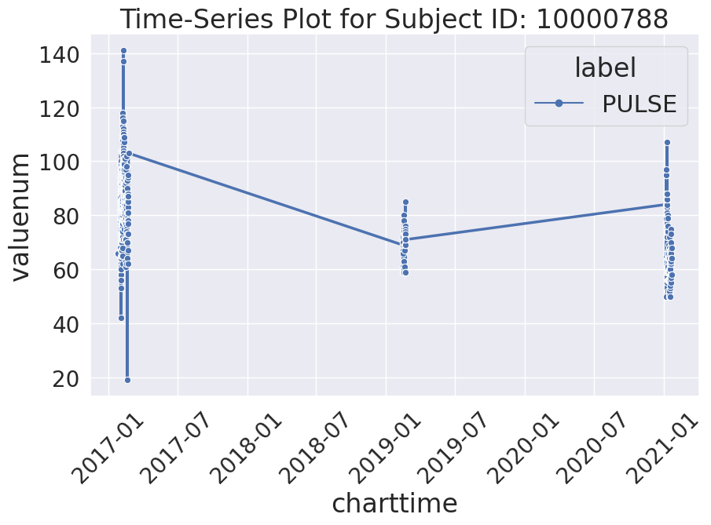

```python
df = con.sql(f"""
SELECT subject_id, hadm_id
, c.itemid, di.label
, charttime, value, valuenum, valueuom
FROM chartevents c
INNER JOIN d_items di
ON c.itemid = di.itemid
WHERE subject_id = {subject_id}
AND c.itemid = 220045
AND valuenum IS NOT NULL
ORDER BY charttime
""").df()

plt.figure(figsize=(10,6))
sns.lineplot(x='charttime', y='valuenum', hue='label', style='label',
             data=df, markers=True, dashes=False, linewidth=2.5)

plt.xticks(rotation=45)
plt.title(f"Time-Series Plot for Subject ID: {subject_id}")
plt.show()
```

Keep in mind, this just scanned over 573,254,118 rows in less than a second to get this data, and did not load any of it into memory.

Looking at the plot, it looks strange. This is because the person had multiple admissions spread out over years. We should specify a single admission. Let's pick the one associated with their first ICU stay.

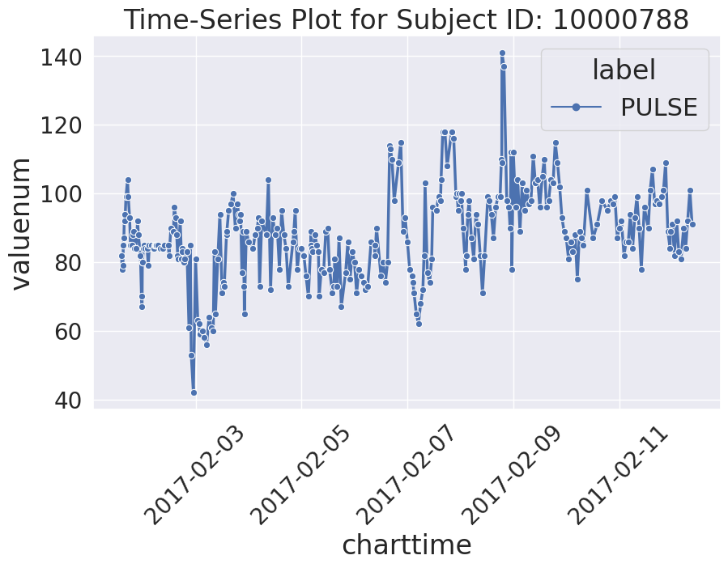

```python
df = con.sql(f"""
SELECT c.subject_id, c.hadm_id
, c.itemid, di.label
, charttime, value, valuenum, valueuom
FROM chartevents c
INNER JOIN (
  SELECT subject_id, intime, outtime
  FROM icustays
  WHERE subject_id = {subject_id}
  ORDER BY intime
  LIMIT 1
) i
  ON c.subject_id = i.subject_id
  AND c.charttime >= i.intime
  AND c.charttime <= i.outtime
INNER JOIN d_items di
ON c.itemid = di.itemid
WHERE c.subject_id = {subject_id}
AND c.itemid = 220045
AND valuenum IS NOT NULL
ORDER BY charttime
""").df()

plt.figure(figsize=(10,6))
sns.lineplot(x='charttime', y='valuenum', hue='label', style='label',
             data=df, markers=True, dashes=False, linewidth=2.5)

plt.xticks(rotation=45)
plt.title(f"Time-Series Plot for Subject ID: {subject_id}")
plt.show()
```